```python
pip install pandas statsmodels matplotlib
```

# 1. Lectura y gestión de datos

```python
import pandas as pd
import numpy as np
import warnings
warnings.filterwarnings('ignore')

# Leer los datos desde un archivo CSV
data = pd.read_csv('/content/electricity_price_demand.csv')

# Visualizar los datos
print(data.head())
print(data.info())

# Convertir la columna de fechas a tipo datetime
data['date'] = pd.to_datetime(data['date'])

# Establecer la columna de fechas como índice
data.set_index('date', inplace=True)

# Convertir columnas categóricas a tipo 'category'
data['school_day'] = data['school_day'].astype('category')
data['holiday'] = data['holiday'].astype('category')


# Establecer la frecuencia en el índice de fechas
data = data.asfreq('D')

# Comprobar que no haya valores faltantes
print("Valores faltantes en 'demand':", data['demand'].isna().sum())

# Comprobar características
print(data.info())
```

```
         date      demand        RRP  demand_pos_RRP  RRP_positive  \
0  2015-01-01   99635.030  25.633696       97319.240     26.415953
1  2015-01-02  129606.010  33.138988      121082.015     38.837661
2  2015-01-03  142300.540  34.564855      142300.540     34.564855
3  2015-01-04  104330.715  25.005560      104330.715     25.005560
4  2015-01-05  118132.200  26.724176      118132.200     26.724176

   demand_neg_RRP  RRP_negative  frac_at_neg_RRP  min_temperature  \
0        2315.790     -7.240000         0.020833             13.3
1        8523.995    -47.809777         0.062500             15.4
2           0.000      0.000000         0.000000             20.0
3           0.000      0.000000         0.000000             16.3
4           0.000      0.000000         0.000000             15.0

   max_temperature  solar_exposure  rainfall school_day holiday
0             26.9            23.6       0.0          N       Y
1             38.8            26.8       0.0          N       N
2             38.2            26.5       0.0          N       N
3             21.4            25.2       4.2          N       N
4             22.0            30.7       0.0          N       N
<class 'pandas.core.frame.DataFrame'>
RangeIndex: 2106 entries, 0 to 2105
Data columns (total 14 columns):
 #   Column           Non-Null Count  Dtype
---  ------           --------------  -----
 0   date             2106 non-null   object
 1   demand           2106 non-null   float64
 2   RRP              2106 non-null   float64
 3   demand_pos_RRP   2106 non-null   float64
 4   RRP_positive     2106 non-null   float64
 5   demand_neg_RRP   2106 non-null   float64
 6   RRP_negative     2106 non-null   float64
 7   frac_at_neg_RRP  2106 non-null   float64
 8   min_temperature  2106 non-null   float64
 9   max_temperature  2106 non-null   float64
 10  solar_exposure   2105 non-null   float64
 11  rainfall         2103 non-null   float64
 12  school_day       2106 non-null   object
 13  holiday          2106 non-null   object
dtypes: float64(11), object(3)
```

[output cut: 10 more lines]

```
 1   RRP              2106 non-null   float64
 2   demand_pos_RRP   2106 non-null   float64
 3   RRP_positive     2106 non-null   float64
 4   demand_neg_RRP   2106 non-null   float64
 5   RRP_negative     2106 non-null   float64
 6   frac_at_neg_RRP  2106 non-null   float64
 7   min_temperature  2106 non-null   float64
 8   max_temperature  2106 non-null   float64
 9   solar_exposure   2105 non-null   float64
 10  rainfall         2103 non-null   float64
 11  school_day       2106 non-null   category
 12  holiday          2106 non-null   category
dtypes: category(2), float64(11)
memory usage: 201.8 KB
None
```

# 2. Identificación de tendencia y estacionalidad

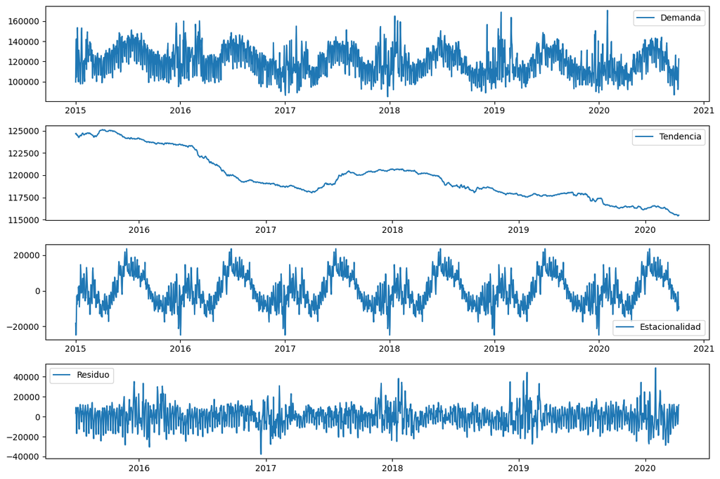

```python
import matplotlib.pyplot as plt
from statsmodels.tsa.seasonal import seasonal_decompose

# Descomponer la serie temporal
result = seasonal_decompose(data['demand'], model='additive', period =365)

# Graficar los componentes de la descomposición
plt.figure(figsize=(12, 8))
plt.subplot(411)
plt.plot(data['demand'], label='Demanda')
plt.legend(loc='best')
plt.subplot(412)
plt.plot(result.trend, label='Tendencia')
plt.legend(loc='best')
plt.subplot(413)
plt.plot(result.seasonal, label='Estacionalidad')
plt.legend(loc='best')
plt.subplot(414)
plt.plot(result.resid, label='Residuo')
plt.legend(loc='best')
plt.tight_layout()
plt.show()
```

**Demanda (Serie Original)**: Este gráfico muestra la demanda de electricidad a lo largo del tiempo. Observamos fluctuaciones diarias y estacionales, con algunos picos y valles que indican variaciones en la demanda.

**Tendencia**: En este caso, la tendencia es descendente, lo que sugiere que la demanda de electricidad ha disminuido gradualmente durante el período analizado.

**Estacionalidad**: Este gráfico muestra los patrones estacionales recurrentes en los datos de demanda. La estacionalidad se repite de forma regular en intervalos de tiempo específicos. Aquí, se observan ciclos anuales con variaciones similares en las mismas épocas cada año. Esto indica que hay una fuerte componente estacional en la demanda de electricidad.

**Residuo**: Este gráfico muestra el residuo, es decir, la parte de la serie temporal que representa las fluctuaciones aleatorias y los errores que no son explicados por la tendencia o la estacionalidad. En este caso, los residuos parecen ser relativamente estables, aunque con algunos picos que podrían ser eventos excepcionales.

# 3. Aplicación del suavizado exponencial

En el contexto de esta serie temporal de demanda de electricidad, que tiene una tendencia y una componente estacional claras, el suavizado exponencial más adecuado sería el suavizado exponencial triple, también conocido como el modelo de Holt-Winters. Este modelo tiene en cuenta los tres componentes: nivel, tendencia y estacionalidad.

```python
from statsmodels.tsa.holtwinters import ExponentialSmoothing

# Dividir los datos en entrenamiento y prueba
train_data = data[:'2018-12-31']
test_data = data['2019-01-01':]

# Ajustar el modelo de suavizado exponencial (Holt-Winters)
model = ExponentialSmoothing(train_data['demand'], trend='add', seasonal='add', seasonal_periods=365).fit()

# Hacer una predicción en el conjunto de prueba
pred = model.forecast(steps=len(test_data))
```

# 4. Visualización de los resultados

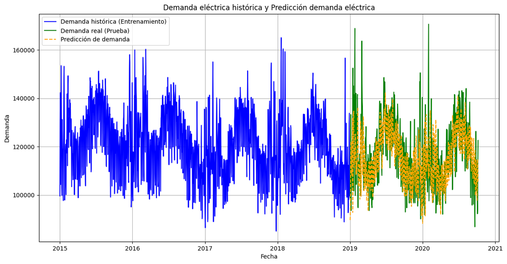

```python
# Graficar los datos históricos y las predicciones
plt.figure(figsize=(14, 7))
plt.plot(train_data.index, train_data['demand'], label='Demanda histórica (Entrenamiento)', color='blue')
plt.plot(test_data.index, test_data['demand'], label='Demanda real (Prueba)', color='green')
plt.plot(test_data.index, pred, label='Predicción de demanda', linestyle='--', color='orange')
plt.xlabel('Fecha')
plt.ylabel('Demanda')
plt.title('Demanda eléctrica histórica y Predicción demanda eléctrica')
plt.legend()
plt.grid(True)
plt.show()
```

# 5. Evaluación de las predicciones mediante Mean Absolute Percentage Error (MAPE)

```python
from sklearn.metrics import mean_squared_error, mean_absolute_error
mape = np.mean(np.abs((test_data['demand'] - pred) / test_data['demand'])) * 100
print(f'MAPE: {mape}')
```

```
MAPE: 10.376495514010745
```

**Mean Absolute Percentage Error (MAPE)**: Es el promedio de los errores porcentuales absolutos entre los valores predichos y los valores reales. Nuestro MAPE es del 10.38%, lo que sugiere que, en promedio, las predicciones están un 10.38% fuera de los valores reales. Por tanto, podemos afirmar que el modelo tiene un rendimiento bastante bueno.

**Rangos típicos**:

Menos del 10%: Excelente.

Entre 10% y 20%: Bueno.

Entre 20% y 50%: Aceptable.

Más del 50%: Deficiente.

# Exportar el notebook a formato HTML

```python
from google.colab import files
import nbformat
from nbconvert import HTMLExporter

# Cargar el archivo del notebook
notebook_filename = '/content/Serie_temporal_demanda_electrica.ipynb'
with open(notebook_filename) as f:
    notebook_content = nbformat.read(f, as_version=4)

# Exportar a HTML
html_exporter = HTMLExporter()
(body, resources) = html_exporter.from_notebook_node(notebook_content)

# Guardar el archivo HTML
with open('notebook_exportado.html', 'w') as f:
    f.write(body)

# Descargar el archivo HTML
files.download('notebook_exportado.html')
```